# act_report

## Report: act_report

- Create a **250-word-minimum written report** called "act_report.pdf" or "act_report.html" that communicates the insights and displays the visualization(s) produced from your wrangled data. This is to be framed as an external document, like a blog post or magazine article, for example.

### Insights:

1.Based on the data analysis fromthe project, the max retweet count got for tweet_id =744234799360020481. Unfortunately, we don't have name for this dog. But the p1 predcition is golden_retriever.Its a dogggo.It's also got max_like_count.

2.Duddles got max quote count.Based on the predictions it may be english_springer or boston_bull or cardigan type.

#### p1,p2,p3 confidence means for True and False groups

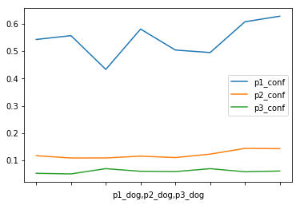

Based on the above diagram it shows the mean prediction of p1 confidence is greater than p2 confidence and p3 confidence. P3 prediction confidence mean is smaller than all prediction confidence rates.